# ENG

# Atlantic Bluefin Tuna MSE

## (*Thunnus thynnus*)

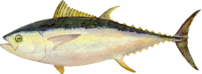

# Overview

## Atlantic bluefin tuna exhibits complex dynamics involving two stocks (eastern and western), characterized by long-distance movements and mixed-stock fisheries. Management Strategy Evaluation (MSE) for Atlantic bluefin tuna, incorporating stock mixing between the two stocks, has been under development since at least 2014. Following substantial efforts by both the SCRS and the Commission, a Management Procedure (MP) was adopted in 2022 (Rec. 22-09), and Total Allowable Catches (TACs) for both stocks were set for 2023–2025 based on this MP (East: Rec. 22-08; West: Rec. 22-10). The Commission also adopted the Exceptional Circumstances (EC) protocol in 2023 (Rec. 23-07, Annex 4), which includes annual evaluation of ECs by the SCRS. No ECs have been invoked since its adoption. The SCRS has scheduled the application of the MP in 2025 to set TACs for the period 2026-2028. In addition, the Commission plans to conduct a stock assessment and review the Operating Models (OMs) and the MP over 2026-2028.

## OM Developed in 2014-2021

## Recondition in 2028

## MP Adopted in 2022

## MP since 2022

## ECP adopted in 2023

## EC evaluation No EC since 2023

# History

## A detailed account of the Management Strategy Evaluation (MSE) process for Atlantic bluefin tuna (BFT) is available in the SCRS Reports and in the documents and activity reports of the ICCAT Atlantic-Wide Research Programme for Bluefin Tuna (GBYP). The BFT MSE process was initiated in 2013 with a kick-off meeting held in Gloucester, USA (Anon., 2013). During the development of the Operating Models (OMs), the SCRS began consultations with Panel 2 in 2019 to define operational management objectives, as outlined in Resolution 18-03. Following the adoption of the OMs in 2021 (Anon., 2021), the SCRS focused on the development and evaluation of candidate Management Procedures (MPs), and maintained regular engagement with the Commission to support the adoption process. This engagement was facilitated through intersessional meetings and a series of “Ambassadors webinars,” which were used to communicate MSE results to stakeholders and decision-makers. In 2023, the Commission adopted the Exceptional Circumstances Protocol (Rec. 23-07, Annex 4). These milestones represent the culmination of a decade-long, iterative process to establish a scientifically robust and operationally viable management framework for Atlantic bluefin tuna.

# Contents

## Operating Models

## Management Objectives

## Candidate Management Procedure

## Management Procedure

## Exceptional Circumstances

## References

# Operating Models

## The SCRS developed a novel population dynamics model for the Atlantic bluefin tuna Operating Models (OMs) that explicitly accounts for stock mixing between the two biological populations. This model integrates multiple data sources, including otolith microchemistry, genetic analyses, and electronic tagging data. The development of this modelling framework required several years of effort, beginning around 2015, and culminating in the adoption of the OMs in 2021. Progress was partly constrained by the need for the SCRS to also conduct full stock assessments for the eastern and western Atlantic bluefin tuna stocks in 2017 (E/W), 2020 (E/W), 2021 (W), and 2022 (E). The adoption of these OMs in 2021 represented a significant milestone in addressing the complexities associated with stock mixing, achieved despite the concurrent demands of multiple assessment cycles.

# Materials

## More materials can be found in Reference

## [Summary](https://iccat.github.io/abft-mse/)

## [MSE Codes](https://iccat.github.io/iccat-mse-web/species/BFT/BFT_readme.html)

## [Shiny App](https://iccat.shinyapps.io/ABTMSE/)

# Management Objectives

# [**Rec. 22-09**](https://www.iccat.int/Documents/Recs/compendiopdf-e/2022-09-e.pdf)

## Stock Status

## Prob. >= 60% in green quadrant for both W,E stocks

## Safety

## Prob. < 15% of stock falling below Blim

## Yield

## Maximize overall catch in both W,E areas

## Stability

## TAC changes between periods +20%/-35%

# Candidate Management Procedure

## Seven Candidate Management Procedures (CMPs) were initially developed since 2019, following 2 CMPs were sent to the Commission for their final selection in 2022. - CMP-BR by Butterworth Rademeyer - CMP-LW by Lauretta et al.

# Management Procedure

## The Commission adopted the BR Management Procedure in 2022 (Rec.22-09, Annex 2).

## The BR Management Procedure (MP) is an empirical approach that utilizes standardized abundance indices as its primary input. These indices are initially standardized for magnitude and subsequently aggregated using a weighted average of ten indices representing both the eastern and western Atlantic areas. The resulting composite index is then smoothed over three years to reduce the influence of observation error and interannual variability. Total Allowable Catches (TACs) are determined by applying a fixed harvest rate to the estimated abundance, as derived from the aggregated and smoothed indices.

## Rec. 22-09 Annex 2

# Exceptional Circumstances

## The Commission adopted the Exceptional Circumstances Protocol in 2023 (Rec.23-07 Annex 4).

## The SCRS have evaluated Exceptional Circumstances annually since 2023, and there have been no Exceptional Circumstances declared yet.

## Principles of ECs

## a: When there is evidence that the stock and/or fishery dynamics are in states not previously considered to be plausible in the context of the management strategy evaluation (MSE); b: When there is evidence that the data required to apply the management procedure (MP) are not available or sufficient, or are no longer appropriate; and/or, c: When there is evidence that total catch for either the West area or the East area is above the total allowable catch (TAC) for the respective area set using the MP.

## EC Protcol: Rec. 23-07, Annex 4

# References

## Materials

## Rec/Res

## Meetings

## SCRS Docs

## Others

## Updated: July 7, 2025

## Copyright © 2025 ICCAT. All rights reserved